# Bio-Economic Selection Toolbox for Marine Protected Areas - BESTMPA R Package

Remi Daigle

Thank you for your interest in the R package for the bioeconomic evaluation of MPA network design! If you haven’t already done so, please refer to the [manuscript](https://f1000research.com/articles/4-1234/v1) describing the model results.

## Usage

If you would like to use this package to your own scenario, please fork this repository and modify as needed, or install the package directly from GitHub.

```r
install.packages("devtools")
library(devtools)
install_github("remi-daigle/BESTMPA@gh-pages")
```

We kindly ask that you cite both the original manuscript and this repository in any resulting publication. We recognize that there are some aspects of the model the could be closer to reality and we look forward to seeing how you would improve it. To make changes, we recommend starting with the code in this vignette (or the index.Rmd)

If you would like to replicate our results, download the repository as is and run the simulations by running the code in index.Rmd. This script will contains all the user defined parameters, and the functions are all contained within the [R/](https://github.com/remi-daigle/BESTMPA/tree/gh-pages/R) directory if you would like to inspect and or modify them individually.

```r
require(BESTMPA)
require(rgdal)
require(rgeos)
require(raster)
require(igraph)
require(ggplot2)
require(tidyverse)
require(data.table)
require(gridExtra)
require(grid)
require(spdep)
require(Matrix)
require(Grid2Polygons)
require(plotrix)
```

## Housekeeping

Before getting started, using the housekeeping function will prepare the environment and your file structure for modelling. This function will conveniently create a results folder, clear the environment, figures, delete previous results, and increase the memory limit if desired.

```r
results_folder <- "BESTMPA_results"
housekeeping(results_folder=results_folder,env=TRUE,fig=TRUE,delete=FALSE,memorylimit=memory.limit())
```

## Spatial Baselayer

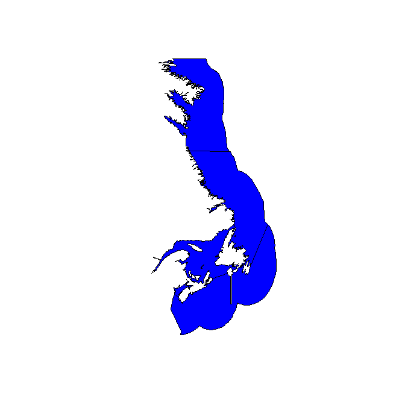

```r
EEZ <- readOGR(dsn=paste0(getwd(),"/shapefiles"),layer="eez_iho_union_v2")
plot(EEZ, col='blue')
```

Let’s Remove Canadian part of the Davis Strait for EEZ since it’s beyond cod’s normal habitat.

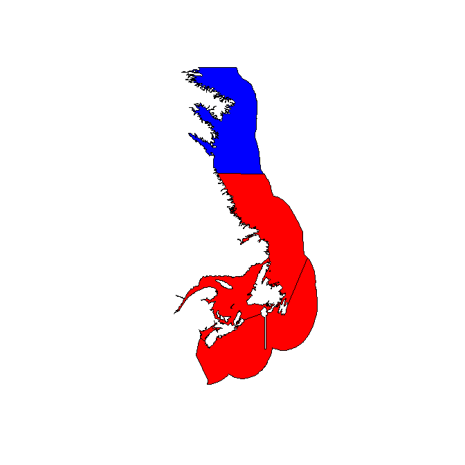

```r
plot(EEZ, col='blue')
EEZ <- EEZ[EEZ$marregion!="Canadian part of the Davis Strait",]
plot(EEZ, col='red',add=T)
```

### Load cod habitat and breeding sites

The BESTMPA package is able to exclude certain habitats, or include them by default or as a priority (i.e. that habitat will be selected before proceeding to others). We’re loading cod habitat and breeding grounds generated by georeferencing figure 2 from Lough (2004).

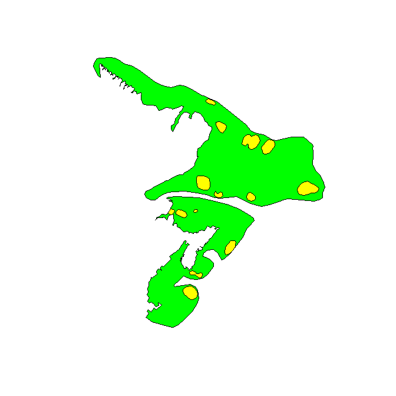

```r
Habitats <- readOGR(dsn=paste0(getwd(),"/shapefiles"),layer="cod_habitat")
plot(Habitats,col='green')
Breeding <- readOGR(dsn=paste0(getwd(),"/shapefiles"),layer="cod_breeding")[2:15,] # remove first Breeding zone, outside EEZ
plot(Breeding,col='yellow',add=T)
```

### Establish basic grid

Define `cell_size` in m, minimum size of MPA’s in number of `cells`, default projection and which areas to include in the grid’s dataframe

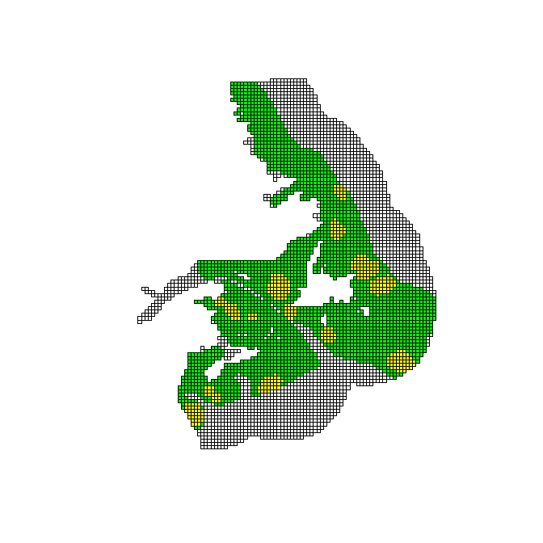

```r
# cell size in m
cell_size <- 20000

# minimum size of MPA
cells=1

# default projection
proj  <- "+proj=utm +zone=20 +datum=NAD83 +units=m +no_defs +ellps=GRS80 +towgs84=0,0,0"
EEZ <- spTransform(EEZ,proj)

# create grid
p <- initgrid(EEZ,cell_size,proj,areas=c(Habitats=Habitats,Breeding=Breeding))

plot(p)
plot(p[p$Habitats==1,],col='green',add=T)
plot(p[p$Breeding==1,],col='yellow',add=T)
```

### Create protection scenarios

Define basic parameters for protection scenarios:

```r
# load existing MPAS
oldMPA <- readOGR(dsn=paste0(getwd(),"/shapefiles"),layer="MPAs_mar")
oldMPA <- spTransform(oldMPA,CRS(proj))

#remove those smaller than cell size
oldMPA <- oldMPA[gArea(oldMPA,byid = TRUE)>=cell_size^2,]

oldMPA <- apply(gCovers(oldMPA,p,byid = TRUE),1,any)|apply(gOverlaps(oldMPA,p,byid = TRUE),1,any)

# number of replicates
replicates <- 1:100

# target protection level in proportion (e.g. 0.2 is 20% protection)
MPA_coverage <- 0.10

# fixed distance for setting MPA distance in km in fixed distance scenario
fixdist <- 75000
```

This is how the four scenarios were created. This portion of code is a little time consuming; therefore, I write the grid to file. If using the index.Rmd and want to generate new scenarios, remove the `eval=FALSE` option from the chunk below

```r
#### set status-quo scenario ####
p <- addscenario(domain=p,included=oldMPA,replicates=replicates,name="MPA_SQ",cells=cells)

#### set maximum distance ####
p <- addscenario(domain=p,included=oldMPA,MPA_coverage=MPA_coverage,replicates=replicates,name="MPA_MD",cell_size=cell_size,cells=cells)

#### set fixed distance ####
p <- addscenario(domain=p,included=oldMPA,MPA_coverage=MPA_coverage,replicates=replicates,dist=fixdist,name="MPA_FX",cell_size=cell_size,cells=cells)

#### set targeted scenario ####
p <- addscenario(domain=p,included=oldMPA,priority=p$Habitats,excluded=p$Breeding,MPA_coverage=MPA_coverage,replicates=replicates,dist=fixdist,name="MPA_TR",cell_size=cell_size,cells=cells)

writeOGR(p,dsn="shapefiles",layer="master_polygon",driver="ESRI Shapefile",overwrite_layer = TRUE)
```

```r
p <- readOGR(dsn="shapefiles",layer="master_polygon")
```

Or you can plot all of the scenarios statically

```r
# protect_scen_colour <- c("purple","green","red","blue")
protect_scen_colour <- c("#D01C8B","#F1B6DA","#B8E186","#4DAC26")
protect_scen_names <- c("Status Quo", "Maximum Distance", "Fixed Distance" , "Targeted")
res <- 400
qual <- 100
textsize <- 10
# list scenarios for looping
scenarios <- names(p)[grep("MPA_",names(p))] # assumes all scenarios begin with "MPA_"
scenarios <- scenarios[order(as.numeric(substr(scenarios,8,nchar(scenarios))))]
if(!file.exists(paste0(results_folder,"/figures"))) dir.create(paste0(results_folder,"/figures"))

for(r in replicates){
    if(r==1){
        jpeg(paste0(results_folder,'/figures/f1_scenarios.jpg'),height=20,width=17,units="cm",res=res,qual=qual)
    } else {
        jpeg(paste0(results_folder,'/figures/fA',r-1,'_scenarios.jpg'),height=20,width=17,units="cm",res=res,qual=qual)
    }

    layout(matrix(c(1,2,3,4),nrow=2))
    par(mar=c(1,1,1,1))
    nam <- names(p)[grep(paste0("MPA_.._",r,"$"),names(p))]
    for(s in nam){
        plot(EEZ)
        plot(p[p[[s]]==1,],col=protect_scen_colour[nam==s],add=T,border='transparent')
        title(protect_scen_names[which(nam==s)])
    }
    dev.off()
}
```